# Equilibrium dynamics in tandem repeat arrays

## The growth problem

In the standard reCYCLing simulation, a tandem repeat array grows from a small initial copy number until it reaches a target size (`max_units`). But in real genomes, repeat arrays don’t grow without bound — they reach a characteristic size that reflects a balance between expansion and contraction forces.

Can we reproduce this equilibrium in simulation?

## Two kinds of duplication, one kind of deletion

The simulator has three forces that change array size:

| Force | Rate type | Effect on size |
| --- | --- | --- |
| **Local duplication** | Per-unit per-gen | Grows faster as array gets bigger |
| **Distal duplication** | Per-array per-gen | Constant injection regardless of size |
| **Chunk deletion** | Per-unit per-gen | Shrinks faster as array gets bigger |

Local duplication and deletion both scale with array size. If their rates and chunk sizes are similar, they roughly cancel — but the array does a random walk that eventually hits zero (extinction).

**Distal duplication is the key to equilibrium.** Because it’s a per-array event (one crossover per generation, independent of array size), it acts as a constant source of new material. As the array grows, per-unit deletion increases until it balances the distal input. The result: a stable equilibrium size.

## Demonstrating equilibrium

Let’s run simulations with different deletion rates while keeping distal duplication fixed, and watch the array size over time.

```r
params <- list(
  list(name = "Low deletion (5e-6)",    pdel = 5e-6),
  list(name = "Medium deletion (5e-5)", pdel = 5e-5),
  list(name = "High deletion (7e-5)",   pdel = 7e-5),
  list(name = "Very high deletion (2e-4)", pdel = 2e-4)
)

trajectories <- rbindlist(lapply(params, function(p) {
  sim <- suppressWarnings(run_sim_ps(
    max_units = 200000, max_t = 5000, hard_cap = 200000,
    init_l = 178, init_k0 = 10,
    p_local_dup = 1e-5,      # low local dup
    p_distal_dup = 0.05,     # 5% chance of crossover per generation
    p_del_chunk = p$pdel,
    mu_total = 5e-5,
    verbose = FALSE, compute_pairs = FALSE
  ))
  data.table(
    gen = seq_along(sim$L_vec),
    size = sim$L_vec,
    scenario = p$name
  )
}))
```

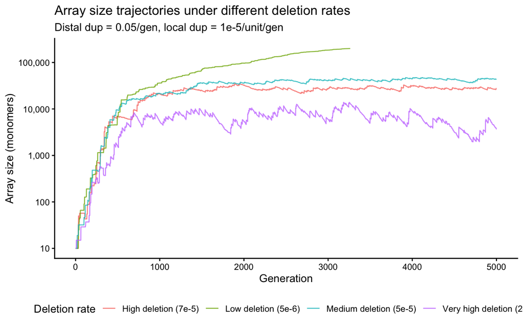

```r
ggplot(trajectories, aes(x = gen, y = size, colour = scenario)) +
  geom_line(linewidth = 0.5, alpha = 0.8) +
  scale_y_log10(labels = scales::comma) +
  theme_classic(base_size = 12) +
  labs(x = "Generation", y = "Array size (monomers)",
       colour = "Deletion rate",
       title = "Array size trajectories under different deletion rates",
       subtitle = "Distal dup = 0.05/gen, local dup = 1e-5/unit/gen") +
  theme(legend.position = "bottom")
```

With low deletion, the array grows without bound. With higher deletion rates, the array reaches an equilibrium size where distal duplication input balances deletion loss. The equilibrium size decreases as deletion rate increases.

## Equilibrium size depends on the balance of forces

Let’s measure the equilibrium size across a range of deletion rates.

```r
del_rates <- 10^seq(-5.5, -3, by = 0.25)

eq_data <- rbindlist(lapply(del_rates, function(pdel) {
  sim <- suppressWarnings(run_sim_ps(
    max_units = 200000, max_t = 5000, hard_cap = 200000,
    init_l = 178, init_k0 = 10,
    p_local_dup = 1e-5, p_distal_dup = 0.05,
    p_del_chunk = pdel, mu_total = 5e-5,
    verbose = FALSE, compute_pairs = FALSE
  ))
  lv <- sim$L_vec
  n <- length(lv)
  # Use last 20% as equilibrium estimate
  tail_start <- max(1, as.integer(n * 0.8))
  tail_vals <- lv[tail_start:n]
  data.table(
    p_del = pdel,
    eq_size = mean(tail_vals),
    eq_sd = sd(tail_vals),
    n_gens = n,
    final = lv[n]
  )
}))
```

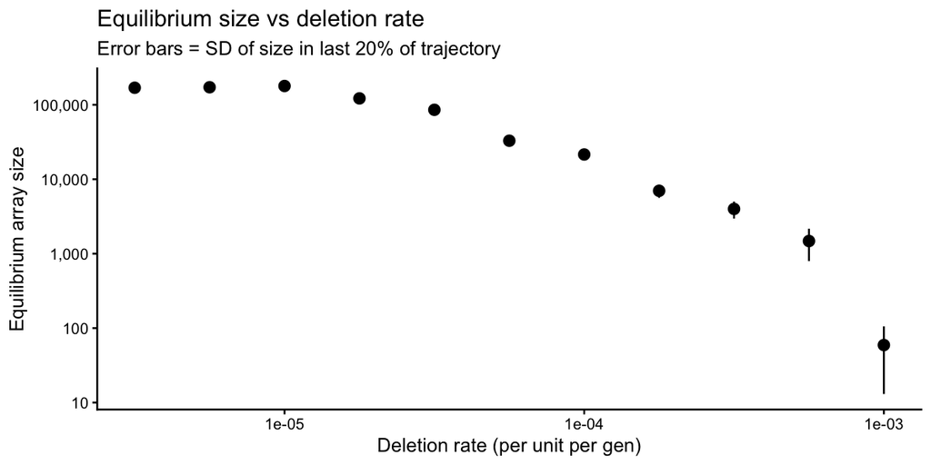

```r
ggplot(eq_data, aes(x = p_del, y = eq_size)) +
  geom_pointrange(aes(ymin = eq_size - eq_sd, ymax = eq_size + eq_sd)) +
  scale_x_log10() +
  scale_y_log10(labels = scales::comma) +
  theme_classic(base_size = 12) +
  labs(x = "Deletion rate (per unit per gen)",
       y = "Equilibrium array size",
       title = "Equilibrium size vs deletion rate",
       subtitle = "Error bars = SD of size in last 20% of trajectory")
```

## Tracking array properties over time

```r
library(cowplot)

# Run equilibrium sim with checkpoints every 100 gens
# Lower mutation rate for more realistic load values
max_gen <- 3000
checkpoint_every <- 100
checkpoints <- seq(checkpoint_every, max_gen, by = checkpoint_every)

# We'll run the full sim once, then use L_vec for size trajectory.
# For load and diversity, we need to run in stages using the R backend.
sim_eq <- suppressWarnings(run_sim_ps(
  max_units = 200000, max_t = max_gen, hard_cap = 200000,
  init_l = 178, init_k0 = 10,
  p_local_dup = 1e-5, p_distal_dup = 0.05,
  p_del_chunk = 7e-5, mu_total = 1e-5,
  verbose = FALSE, compute_pairs = FALSE
))

# Size trajectory from L_vec
traj_dt <- data.table(gen = seq_along(sim_eq$L_vec), size = sim_eq$L_vec)

# For the final state, compute load and copy number
mono <- sim_eq$monomers
ct <- counts_long_nogap(mono$bponly)
cons <- ct[symbol == consensus][order(pos)]
load <- mu_load_from_consensus(mono$bponly, cons)

cat("Final array size:", nrow(mono), "\n")
```

```
#> Final array size: 24898
```

```r
cat("Generations:", length(sim_eq$L_vec), "\n")
```

```
#> Generations: 3001
```

```r
cat("Mean mutation load:", round(mean(load), 1), "\n")
```

```
#> Mean mutation load: 5.2
```

```r
cat("Unique sequences:", uniqueN(mono$bponly), "\n")
```

```
#> Unique sequences: 16971
```

```r
# Copy number distribution
cn <- mono[, .N, by = bponly][order(-N)]
cat("Mean copy number:", round(mean(cn$N), 1), "\n")
```

```
#> Mean copy number: 1.5
```

```r
cat("Max copy number:", max(cn$N), "\n")
```

```
#> Max copy number: 125
```

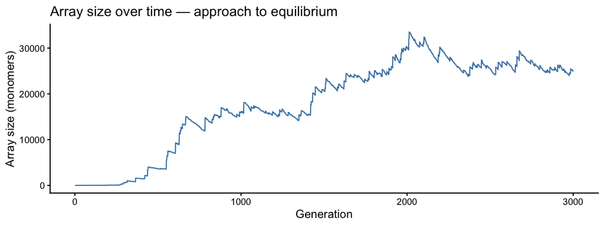

```r
ggplot(traj_dt, aes(x = gen, y = size)) +
  geom_line(colour = "steelblue", linewidth = 0.5) +
  theme_classic(base_size = 11) +
  labs(x = "Generation", y = "Array size (monomers)",
       title = "Array size over time — approach to equilibrium")
```

## Mutation load and diversity at the final state

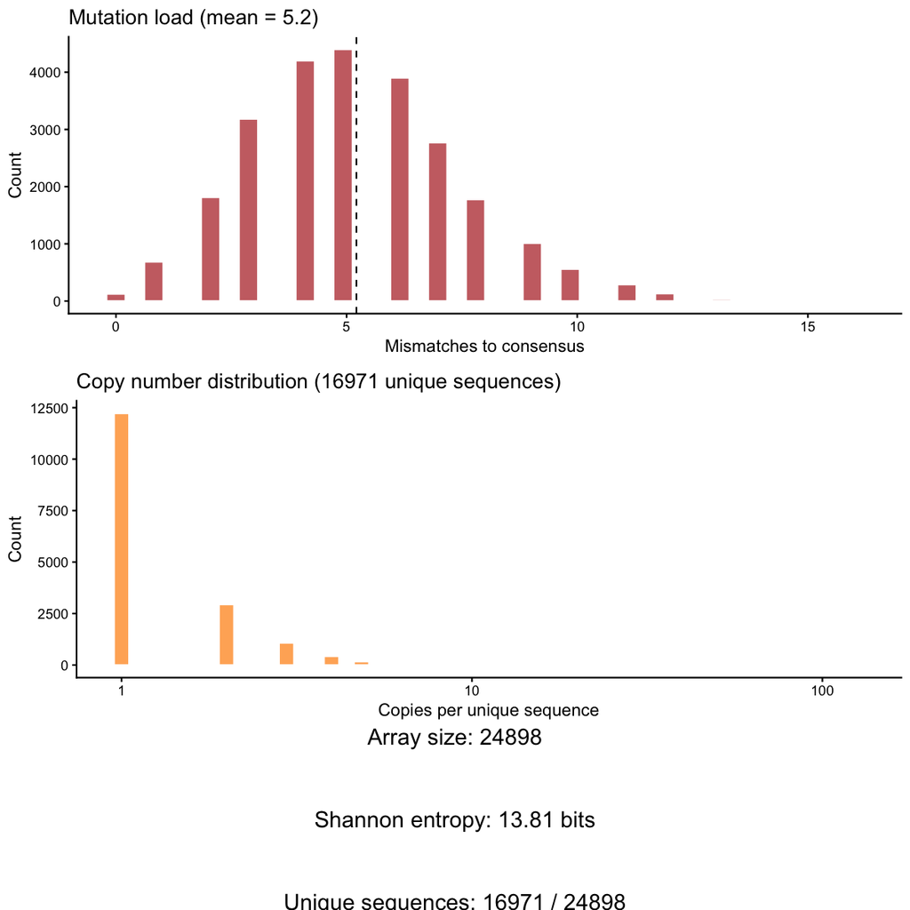

```r
p_load <- ggplot(data.frame(load = load), aes(x = load)) +
  geom_histogram(bins = 40, fill = "firebrick", alpha = 0.7, colour = "white") +
  geom_vline(xintercept = mean(load), linetype = "dashed") +
  theme_classic(base_size = 11) +
  labs(x = "Mismatches to consensus", y = "Count",
       title = paste0("Mutation load (mean = ", round(mean(load), 1), ")"))

p_cn <- ggplot(cn, aes(x = N)) +
  geom_histogram(bins = 50, fill = "darkorange", alpha = 0.7, colour = "white") +
  scale_x_log10() +
  theme_classic(base_size = 11) +
  labs(x = "Copies per unique sequence", y = "Count",
       title = paste0("Copy number distribution (", nrow(cn), " unique sequences)"))

# Shannon entropy as a single number
H <- shannon_entropy(mono$bponly)
p_info <- ggplot() + theme_void() +
  annotate("text", x = 0.5, y = 0.7, size = 5,
           label = paste0("Array size: ", nrow(mono))) +
  annotate("text", x = 0.5, y = 0.5, size = 5,
           label = paste0("Shannon entropy: ", round(H, 2), " bits")) +
  annotate("text", x = 0.5, y = 0.3, size = 5,
           label = paste0("Unique sequences: ", uniqueN(mono$bponly),
                          " / ", nrow(mono)))

plot_grid(p_load, p_cn, p_info, ncol = 1, rel_heights = c(1, 1, 0.5))
```

## Comparing different evolutionary ages

How do array properties change with time? Let’s run simulations of different lengths and compare.

```r
ages <- c(500, 1000, 2000, 3000, 5000)

age_stats <- rbindlist(lapply(ages, function(t_max) {
  sim <- suppressWarnings(run_sim_ps(
    max_units = 200000, max_t = t_max, hard_cap = 200000,
    init_l = 178, init_k0 = 10,
    p_local_dup = 1e-5, p_distal_dup = 0.05,
    p_del_chunk = 7e-5, mu_total = 1e-5,
    verbose = FALSE, compute_pairs = FALSE
  ))
  m <- sim$monomers
  if (nrow(m) < 10) return(NULL)
  ct <- tryCatch(counts_long_nogap(m$bponly), error = function(e) NULL)
  if (is.null(ct)) return(NULL)
  cons <- ct[symbol == consensus][order(pos)]
  ld <- mu_load_from_consensus(m$bponly, cons)
  cn <- m[, .N, by = bponly]
  data.table(
    generations = t_max,
    array_size = nrow(m),
    mean_load = mean(ld),
    median_load = median(ld),
    n_unique = uniqueN(m$bponly),
    mean_copy_number = mean(cn$N),
    max_copy_number = max(cn$N),
    entropy = shannon_entropy(m$bponly)
  )
}))

print(age_stats)
```

```
#>    generations array_size mean_load median_load n_unique mean_copy_number
#>          <num>      <int>     <num>       <num>    <int>            <num>
#> 1:         500      14950 0.8254849           1     1952         7.658811
#> 2:        1000      25018 1.7530178           2     8753         2.858220
#> 3:        2000      30999 3.6118584           3    18300         1.693934
#> 4:        3000      18502 5.2866717           5    13033         1.419627
#> 5:        5000      37403 8.5365612           8    21309         1.755268
#>    max_copy_number   entropy
#>              <int>     <num>
#> 1:            6404  6.366578
#> 2:            4268 10.723827
#> 3:             804 13.612366
#> 4:              78 13.498036
#> 5:              17 14.071341
```

```r
age_long <- melt(age_stats,
  id.vars = "generations",
  measure.vars = c("array_size", "mean_load", "mean_copy_number", "entropy"))
```

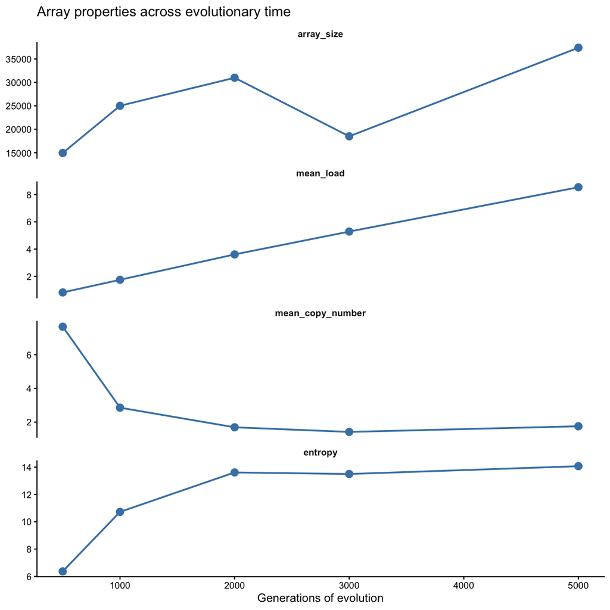

```r
ggplot(age_long, aes(x = generations, y = value)) +
  geom_point(size = 3, colour = "steelblue") +
  geom_line(colour = "steelblue", linewidth = 0.8) +
  facet_wrap(~ variable, scales = "free_y", ncol = 1) +
  theme_classic(base_size = 11) +
  theme(strip.background = element_blank(), strip.text = element_text(face = "bold")) +
  labs(x = "Generations of evolution", y = NULL,
       title = "Array properties across evolutionary time")
```

## The fingerprint at equilibrium

What does the identical-pair structure look like when the array has been evolving at equilibrium for different lengths of time?

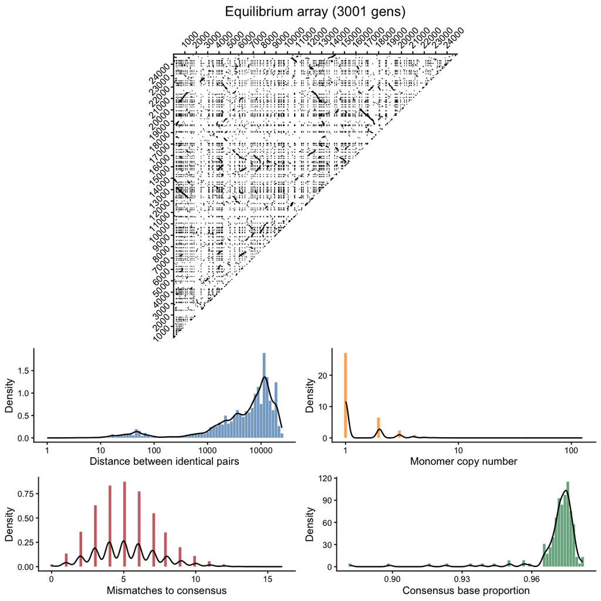

```r
sim_eq_with_pairs <- sim_eq
sim_eq_with_pairs$ps <- pairs_identical(mono)

plot_ps_summary(sim_eq_with_pairs,
  title = paste0("Equilibrium array (", length(sim_eq$L_vec), " gens)"))
```

## Implications for ABC inference

The equilibrium model has important implications for parameter inference:

1. **Array size becomes a summary statistic.** Instead of growing to a preset target, we let the simulation run for a fixed number of generations. The equilibrium size constrains the ratio of duplication to deletion rates.
2. **Mutation load constrains evolutionary time.** Since load ≈ `mu × l × t`, and we know `mu` and `l`, the observed load tells us how many generations the array has been evolving.
3. **The stopping rule changes.** Instead of `max_units`, the simulation runs for a fixed `max_t` (representing real evolutionary time). The ABC then compares the resulting array size, distance distribution, and mutation load against observations.

Key parameters that determine the equilibrium:

- **Distal duplication rate** (per-array): Constant input, independent of size
- **Deletion rate** (per-unit): Size-dependent loss, creates the ceiling
- **Chunk sizes**: Control how much material moves per event
- **Local duplication rate** (per-unit): Amplifies existing structure
- **Mutation rate × time**: Determines divergence/load